# Russian housing price influence factors and forecast

#### num_room

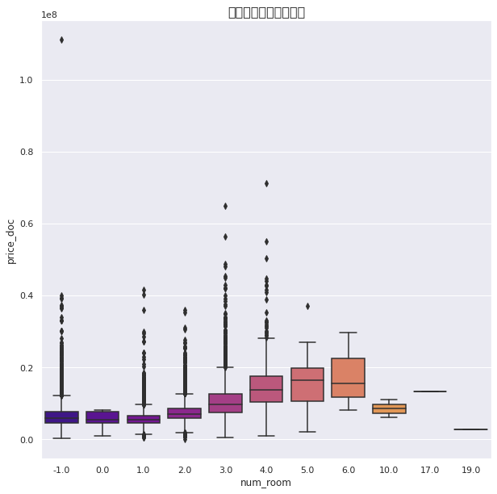

```python
plt.figure(figsize=(10,10))

sns.boxplot(data=data, x=data['num_room'], y=data['price_doc'], palette='plasma')
plt.title('客厅数量对价格的影响',fontweight = 'black',fontsize = 16)

plt.show()
```

可以发现，排除部分异常数据，客厅越多普遍价格越高。

#### floor

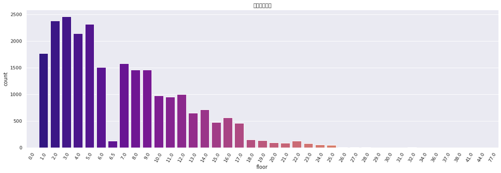

```python
sns.countplot(data['floor'], palette="plasma")
plt.xticks(rotation=60)
fig = plt.gcf()
plt.title('用户喜好楼层')
fig.set_size_inches(20,6)
```

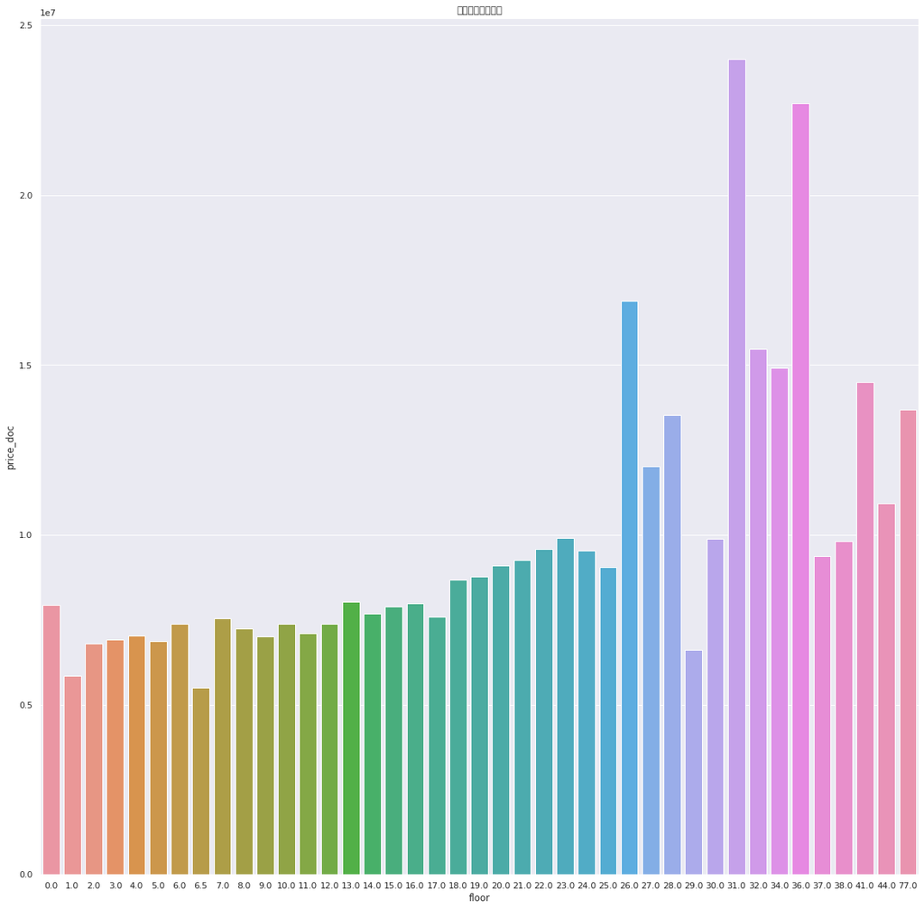

```python
floor_area = data.groupby(['floor'])['price_doc'].aggregate(np.mean).reset_index()
plt.figure(figsize=(20,20))
sns.barplot(x = "floor",y = "price_doc",data = floor_area)
plt.title('楼层与价格的联系')
```

从上面可以知道

1、大部分人购房选择十层以下楼层。

2、普遍楼层高的价格比楼层低的要贵。

#### full_sq

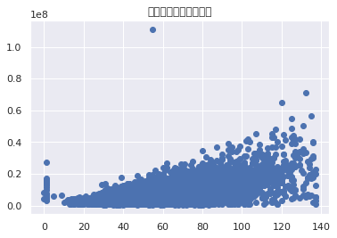

```python
plt.scatter(data['full_sq'], data['price_doc'])
plt.title('房屋面积与价格的关系')
```

可以发现，房屋面积和价格是正相关，意味着越大的房子越贵

### 附近环境

#### big_market_raion

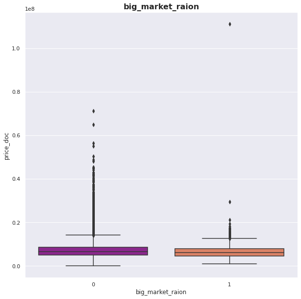

```python
plt.figure(figsize=(10,10))

sns.boxplot(data=data, x=data['big_market_raion'], y=data['price_doc'], palette='plasma')
plt.title('big_market_raion',fontweight = 'black',fontsize = 16)

plt.show()
```

从图中可以看出，是否有大型食品杂货和批发市场的存对销售价格似乎并没有影响

```python
from copy import deepcopy
plt.figure(figsize = (12,4))
def blocks(line):
    if line>=0 and line<=1:
        return '近'
    if line > 1 and line <= 3:
        return '中'
    if line>3:
        return '远'
temp_data = deepcopy(data)
temp_data['school_km'] = temp_data['school_km'].map(blocks)
temp_data['metro_km_walk'] = temp_data['metro_km_walk'].map(blocks)
temp_data['stadium_km'] = temp_data['stadium_km'].map(blocks)
temp_data['railroad_km'] = temp_data['railroad_km'].map(blocks)
temp_data['park_km'] = temp_data['park_km'].map(blocks)
temp_data['catering_km'] = temp_data['catering_km'].map(blocks)
```

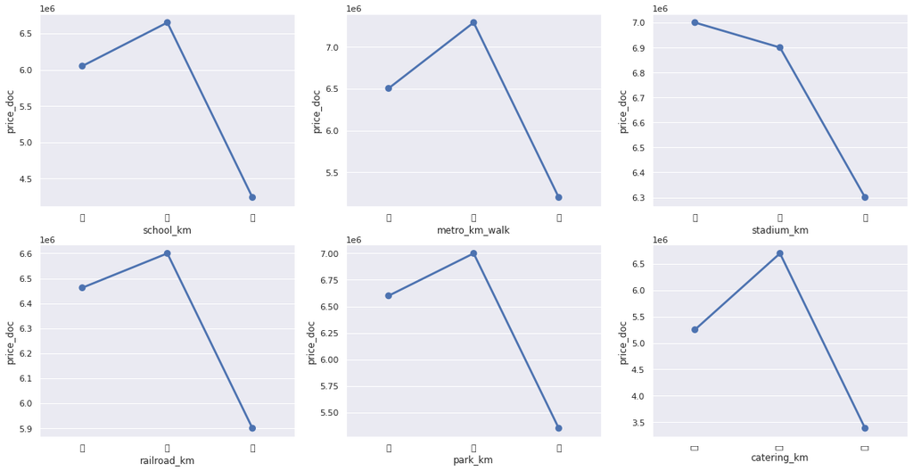

```python
f,ax = plt.subplots(2,3,figsize=(20,10))

temp_df = temp_data.groupby(['school_km'])['price_doc'].aggregate(np.median).reset_index()
metro = temp_data.groupby(['metro_km_walk'])['price_doc'].aggregate(np.median).reset_index()
stadium = temp_data.groupby(['stadium_km'])['price_doc'].aggregate(np.median).reset_index()
railroad = temp_data.groupby(['railroad_km'])['price_doc'].aggregate(np.median).reset_index()
school = temp_data.groupby(['park_km'])['price_doc'].aggregate(np.median).reset_index()
catering = temp_data.groupby(['catering_km'])['price_doc'].aggregate(np.median).reset_index()


sns.pointplot(x='school_km', y='price_doc', label = 'school_km',data=temp_df,ax = ax[0][0])
sns.pointplot(x='metro_km_walk', y='price_doc',label = 'metro_km_walk', data=metro,ax = ax[0][1])
sns.pointplot(x='stadium_km', y='price_doc',label = 'stadium_km', data=stadium,ax = ax[0][2])
sns.pointplot(x='railroad_km', y='price_doc',label = 'railroad_km', data=railroad,ax = ax[1][0])
sns.pointplot(x='park_km', y='price_doc',label = 'park_km', data=school,ax = ax[1][1])
sns.pointplot(x='catering_km', y='price_doc',label = 'catering_km', data=catering,ax = ax[1][2])

plt.xticks(rotation='vertical')
plt.show()
```

在这里我使用了中位数来绘制各种距离的图形，这样可以去减少异常值的影响。

从上可以发现

## Methodology

### 回归

```python
data = train_data[['price_doc','timestamp','full_sq','life_sq','kitch_sq','floor','max_floor','material','build_year',
                   'num_room','state','product_type','sub_area','area_m','raion_popul','park_km','metro_km_walk','stadium_km',
                   'work_all','railroad_km','school_km','big_market_raion','metro_min_avto','additional_education_km','metro_km_avto','cafe_count_5000','public_healthcare_km','big_market_km','public_transport_station_km','theater_km','catering_km','green_zone_km','market_shop_km','ttk_km','kindergarten_km','workplaces_km','oil_chemistry_km','big_road2_km']]
```

```python
#将data中的object类型数据转换为one-hot enconding
from sklearn.preprocessing import OneHotEncoder
from datetime import datetime

data=data.dropna()
data.drop_duplicates(inplace=True)
data = outliners(data,'full_sq',scale=3)
data = outliners(data,'life_sq',scale=3)
data['timestamp'] = pd.to_datetime(data['timestamp'], format = '%Y-%m-%d')
data['big_market_raion'] = data['big_market_raion'].map({'yes':1,'no':0})
data["year"] = data['timestamp'].dt.year
data["month"] = data['timestamp'].dt.month
data["day"] = data['timestamp'].dt.day
data["weekday"] = data['timestamp'].dt.weekday

data_ = data[list(data.columns.drop(['timestamp']))]
invert = {}
cnt = 0
for n,line in enumerate(data_['sub_area']):
    if line in invert.keys():
        continue
    else:
        invert[line] = cnt
        cnt+=1
invert_dict = {"sub_area": invert}
data_ = data_.replace(invert_dict)
data_ = pd.get_dummies(data=data_,columns=data_.select_dtypes(include=['object']).columns.values.tolist())
```

#### 数据划分

```python
from sklearn.model_selection import train_test_split
X = data_[list(data_.columns.drop(['price_doc']))]
Y = data_['price_doc']

x_train, x_test, y_train, y_test = train_test_split(X, Y, test_size=0.3, random_state=1)
print('训练集数量：'+str(x_train.shape))
print('测试集数量：'+str(x_test.shape))
```

```
训练集数量：(10262, 41)
测试集数量：(4398, 41)
```

#### 线性回归模型

```
MSE Test: 9894484663526.553
RMSE Test: 3145549.978
R2_Score Test: 0.539
```

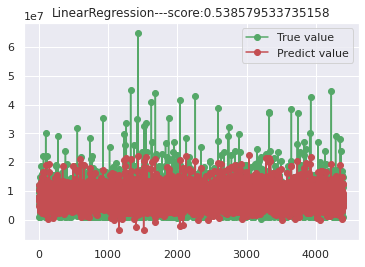

```python
from sklearn.linear_model import LinearRegression
from sklearn.metrics import mean_squared_log_error,mean_squared_error,r2_score

lin_reg = LinearRegression()
lin_reg.fit(x_train,y_train)
y_test_pred = lin_reg.predict(x_test)

mse_lr = mean_squared_error(y_test,y_test_pred)
rmse_lr = np.sqrt((mean_squared_error(y_test,y_test_pred)))
r2_lr = r2_score(y_test,y_test_pred)

print("MSE Test: %.3f" % mse_lr)
print("RMSE Test: %.3f" % rmse_lr)
print("R2_Score Test: %.3f" % r2_lr)

plt.figure()
plt.plot(np.arange(len(y_test_pred)), y_test, "go-", label="True value")
plt.plot(np.arange(len(y_test_pred)), y_test_pred, "ro-", label="Predict value")
plt.title(f"LinearRegression---score:{r2_lr}")
plt.legend(loc="best")
plt.show()
```

#### 决策树模型

```
MSE Test: 14752375440405.385
RMSE Test: 3840882.117
R2_Score Test: 0.312
```

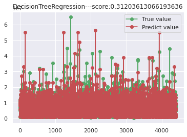

```python
from sklearn.tree import DecisionTreeRegressor

tree_reg = DecisionTreeRegressor()
tree_reg.fit(x_train,y_train)
y_test_pred = tree_reg.predict(x_test)

mse_dt = mean_squared_error(y_test,y_test_pred)
rmse_dt = np.sqrt((mean_squared_error(y_test,y_test_pred)))
r2_dt = r2_score(y_test,y_test_pred)

print("MSE Test: %.3f" % mse_dt)
print("RMSE Test: %.3f" % rmse_dt)
print("R2_Score Test: %.3f" % r2_dt)

plt.figure()
plt.plot(np.arange(len(y_test_pred)), y_test, "go-", label="True value")
plt.plot(np.arange(len(y_test_pred)), y_test_pred, "ro-", label="Predict value")
plt.title(f"DecisionTreeRegression---score:{r2_dt}")
plt.legend(loc="best")
plt.show()
```

[output not shown]

[figure not shown]

```python
from sklearn.linear_model import Lasso
lasso = Lasso(alpha = 5, normalize = True, tol = 0.1)
lasso.fit(x_train,y_train)


mse_La = mean_squared_error(y_test,y_test_pred)
rmse_La = np.sqrt((mean_squared_error(y_test,y_test_pred)))
r2_La = r2_score(y_test,y_test_pred)

print("MSE Test: %.3f" % mse_La)
print("RMSE Test: %.3f" % rmse_La)
print("R2_Score Test: %.3f" % r2_La)
plt.figure()
plt.plot(np.arange(len(y_test_pred)), y_test, "go-", label="True value")
plt.plot(np.arange(len(y_test_pred)), y_test_pred, "ro-", label="Predict value")
plt.title(f"LassoRegression---score:{r2_La}")
plt.legend(loc="best")
plt.show()
```

#### 随机森林模型

```
MSE Test: 7827707614627.153
RMSE Test: 2797804.070
R2_Score Test: 0.635
```

[figure not shown]

```python
from sklearn.ensemble import RandomForestRegressor

forest_reg = RandomForestRegressor(random_state=42)
forest_reg.fit(x_train,y_train)
y_test_pred = forest_reg.predict(x_test)

mse_rf = mean_squared_error(y_test,y_test_pred)
rmse_rf = np.sqrt((mean_squared_error(y_test,y_test_pred)))
r2_rf = r2_score(y_test,y_test_pred)

print("MSE Test: %.3f" % mse_rf)
print("RMSE Test: %.3f" % rmse_rf)
print("R2_Score Test: %.3f" % r2_rf)

plt.figure()
plt.plot(np.arange(len(y_test_pred)), y_test, "go-", label="True value")
plt.plot(np.arange(len(y_test_pred)), y_test_pred, "ro-", label="Predict value")
plt.title(f"LinearRegression---score:{r2_rf}")
plt.legend(loc="best")
plt.show()
```

#### Results and Discussion

```python
result_dict = {'model':['LinearRegression','DecisionTreeRegressor','Lasso','RandomForestRegressor'],'MSE':[mse_lr,mse_dt,mse_La,mse_rf],'RMSE':[rmse_lr,rmse_dt,rmse_La,rmse_rf],'R2':[r2_lr,r2_dt,r2_La,r2_rf]}
result_frame=pd.DataFrame(result_dict)
result_frame
```

[output not shown]

### 分类

此外，考虑到房屋实际上也是有不同的价位区间，客户或许在购房之前会优先考虑一定价位区间的房子，因此，我们将房屋价格划分为4个区间，分别是[<1e6]、[1e6-5e6]、[5e6-1e7]、[>1e7],同样使用随机森林来对房屋进行价格区间分类

#### 划分价格区间

```python
def classes(line):
    if line<=1e6:
        return 0
    if line > 1e6 and line <= 5e6:
        return 1
    if line>5e6 and line<=1e7:
        return 2
    if line>1e7:
        return 3
```

#### 数据划分

```python
from copy import deepcopy

temp_data = deepcopy(data_)
temp_data['price_doc'] = temp_data['price_doc'].map(classes)
from sklearn.model_selection import train_test_split
X = temp_data[list(temp_data.columns.drop(['price_doc']))]
Y = temp_data['price_doc']

x_train, x_test, y_train, y_test = train_test_split(X, Y, test_size=0.3, random_state=1)
print('训练集数量：'+str(x_train.shape))
print('测试集数量：'+str(x_test.shape))
```

```
训练集数量：(10262, 41)
测试集数量：(4398, 41)
```

```python
def get_metrics(y_test,y_predicted):
    """

    :param y_test: 真实值
    :param y_predicted: 预测值
    :return:
    """
    # 精确度=真阳性/（真阳性+假阳性）
    precision=precision_score(y_test,y_predicted,pos_label=None,average='weighted')
    # 召回率=真阳性/（真阳性+假阴性）
    recall=recall_score(y_test,y_predicted,pos_label=None,average='weighted')

    # F1
    f1=f1_score(y_test,y_predicted,pos_label=None,average='weighted')

    # 精确率
    accuracy=accuracy_score(y_test,y_predicted)
    return accuracy,precision,recall,f1
```

```python
from sklearn.ensemble import RandomForestClassifier
from sklearn.metrics import classification_report
from sklearn.metrics import accuracy_score,f1_score,precision_score,recall_score

rfr = RandomForestClassifier().fit(x_train, y_train)
```

#### Results and Discussion

```python
y_predicted_counts = rfr.predict(x_test)
accuracy, precision, recall, f1 = get_metrics(y_test, y_predicted_counts)
print('分类报告:', classification_report(y_test, y_predicted_counts))
print("accuracy=%.6f,precision=%.6f,recall=%.6f,f1=%.6f" % (accuracy, precision, recall, f1))
```

```
分类报告:               precision    recall  f1-score   support

           0       0.13      0.01      0.02       150
           1       0.78      0.47      0.58       849
           2       0.78      0.92      0.84      2498
           3       0.80      0.82      0.81       901

    accuracy                           0.78      4398
   macro avg       0.62      0.55      0.56      4398
weighted avg       0.76      0.78      0.76      4398

accuracy=0.780127,precision=0.760029,recall=0.780127,f1=0.757721
```

```python
df_result = pd.DataFrame(columns=['true', 'predict'])
df_result['true'] = y_test
df_result['predict'] = y_predicted_counts
df_temp = df_result[df_result['true']==0]
df_temp.head(30)
```

|  | true | predict |
| --- | --- | --- |
| 26291 | 0 | 2 |
| 12852 | 0 | 2 |
| 27046 | 0 | 2 |
| 19663 | 0 | 3 |
| 14607 | 0 | 2 |
| 28558 | 0 | 2 |
| 25153 | 0 | 2 |
| 10485 | 0 | 3 |
| 25809 | 0 | 2 |
| 9463 | 0 | 2 |
| 22656 | 0 | 2 |
| 29240 | 0 | 2 |
| 12144 | 0 | 2 |
| 24151 | 0 | 1 |
| 17744 | 0 | 2 |
| 9842 | 0 | 2 |
| 17015 | 0 | 2 |
| 15008 | 0 | 2 |
| 19638 | 0 | 3 |
| 19431 | 0 | 2 |
| 21019 | 0 | 3 |
| 27038 | 0 | 2 |
| 18107 | 0 | 2 |
| 15081 | 0 | 2 |
| 17360 | 0 | 2 |
| 29115 | 0 | 2 |
| 22878 | 0 | 1 |
| 24089 | 0 | 3 |
| 16114 | 0 | 3 |
| 19871 | 0 | 2 |

在此，我们选用了accuracy、recall、precision、f1作为我们分类模型的评价标准。accuracy指的是正确预测的正反例数 /总数; precision指的是预测出是正的里面有多少真正是正的;recall表现出在实际正样本中，分类器能预测出多少;f1是precision和recall的调和值， 更接近于两个数较小的那个，所以precision和recall接近时，F值最大。由上述结果可以看出，房屋价格>1e6时，都有一定的效果，其中当房价>5e6时，f1值均在0.8以上；相反，明显看出当房价低于1e6时，结果基本全部预测错，0类的房价几乎全部预测城2类，由此说明低于1e6房价的数据属于bad case，考虑去除之后在做一版分类结果看看

### 去除bad case后的分类和回归预测

```python
temp_data = deepcopy(data_)
temp_data_no_0 = temp_data[temp_data['price_doc']>1e6]
temp_data_no_0['price_doc'] =temp_data_no_0['price_doc'].map(classes)
#数据划分
from sklearn.model_selection import train_test_split
X = temp_data_no_0[list(temp_data_no_0.columns.drop(['price_doc']))]
Y = temp_data_no_0['price_doc']


x_train, x_test, y_train, y_test = train_test_split(X, Y, test_size=0.3, random_state=1)
print('训练集数量：'+str(x_train.shape))
print('测试集数量：'+str(x_test.shape))
```

```
训练集数量：(9911, 41)
测试集数量：(4248, 41)
```

#### 分类

```python
from sklearn.ensemble import RandomForestClassifier
from sklearn.metrics import classification_report
from sklearn.metrics import accuracy_score,f1_score,precision_score,recall_score
rfr = RandomForestClassifier().fit(x_train, y_train)
y_predicted_counts = rfr.predict(x_test)
accuracy, precision, recall, f1 = get_metrics(y_test, y_predicted_counts)
print('分类报告:', classification_report(y_test, y_predicted_counts))
print("accuracy=%.6f,precision=%.6f,recall=%.6f,f1=%.6f" % (accuracy, precision, recall, f1))
```

```
分类报告:               precision    recall  f1-score   support

           1       0.77      0.46      0.57       790
           2       0.82      0.92      0.87      2564
           3       0.82      0.82      0.82       894

    accuracy                           0.82      4248
   macro avg       0.80      0.73      0.75      4248
weighted avg       0.81      0.82      0.80      4248

accuracy=0.815207,precision=0.811605,recall=0.815207,f1=0.803929
```

#### 回归

可以看到，去除房价小于1e6的数据之后，模型的各项效果均比之前提升将近5%， 有感于此，决定删除房价小于1e6的数据之后再使用随机森林做一次回归预测

```python
data_no_1e6 = data_[data_['price_doc']>1e6]
#数据划分
from sklearn.model_selection import train_test_split
X = data_no_1e6[list(data_no_1e6.columns.drop(['price_doc']))]
Y = data_no_1e6['price_doc']

x_train, x_test, y_train, y_test = train_test_split(X, Y, test_size=0.3, random_state=1)
print('训练集数量：'+str(x_train.shape))
print('测试集数量：'+str(x_test.shape))
```

```
训练集数量：(9911, 41)
测试集数量：(4248, 41)
```

```
MSE Test: 6026729238602.280
RMSE Test: 2454939.763
R2_Score Test: 0.681
```

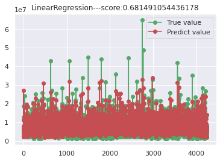

```
score: 0.6815
```

```python
from sklearn.ensemble import RandomForestRegressor

forest_reg = RandomForestRegressor(random_state=42)
forest_reg.fit(x_train,y_train)
#评价方法mse及r2
score = forest_reg.score(x_test, y_test)
y_test_pred = forest_reg.predict(x_test)
print("MSE Test: %.3f" % (mean_squared_error(y_test,y_test_pred)))
print("RMSE Test: %.3f" % np.sqrt((mean_squared_error(y_test,y_test_pred))))
print("R2_Score Test: %.3f" % (r2_score(y_test,y_test_pred)))

plt.figure()
plt.plot(np.arange(len(y_test_pred)), y_test, "go-", label="True value")
plt.plot(np.arange(len(y_test_pred)), y_test_pred, "ro-", label="Predict value")
plt.title(f"LinearRegression---score:{score}")
plt.legend(loc="best")
plt.show()
print('score: %.4f'%(score))
```

#### Results and Discussion

可以看到，去除房价小于1e6的数据之后，回归模型的效果比起原来提升同样有5%，从此处得到一个启发， 进行回归任务时，除了常规的异常值检测，还可以将目标变量分桶进行分类，从而检测出相应的bad case

## Conclusion

在这个项目当中，我们的目的主要是为了解答这样的问题：房屋特征因素与房屋价格之间的关系是什么？，因此，我们采用分析房价影响因素的思路出发，利用影响因素建立指标体系，探讨类似于楼层高度、面积大小、所在区域、附近环境、购房目的等房屋因素与房屋价格之间的关系，由上面的数据分析可以看到大部分房屋因素与房屋价格存在一定的关系，例如，房子面积越大房价越高；房屋附近环境越好，交通越方便，基础设施越完善，房价越高；2012年来用于投资目的的房价一般会比自住目的的房价要高些等等。此外，我们还分析一些房屋购买的信息，例如购房的年月日交易量趋势、投资房屋及自住房屋的热门地区、房屋购买的热门楼层等，也可以为房地产市场提供一些额外的参考信息。最后，我们利用上述数据分析考虑的各种因素进行回归建模预测房屋价格，其中以随机森林回归器取得最好的效果，也证明了我们使用的房屋特征因素一定程度上能有效地预测房价。此外，为了对房价进行价位区间预测，我们使用随机森林分类器来对房价进行分类，分类结果显示房价小于1e6的数据分类效果很差，从而我们把房价小于1e6的数据看作bad case,剔除之后，我们重新做了回归及分类任务，可以发现，效果比起原来提升将近5%。综上所述，房屋特征因素与房屋价格之间存在一定的相关关系，并能够作为有效的特征来对房价进行预测。

## Reference List

[1]曾婷婷. 基于机器学习的房价预测模型研究[D]. 西南科技大学. [2]Rosen S . Hedonic Prices and Implicit Markets: Product Differentiation in Pure Competition[J]. Journal of Political Economy, 1974, 82(1):34-55. [3]Fan C C , Yuan S M , Zhang X , et al. A House Price Prediction for Integrated Web Service System of Taiwan Districts[C]// International Conference on Genetic & Evolutionary Computing. Springer, Singapore, 2017. [4]Vineeth N , Ayyappa M , Bharathi B . House Price Prediction Using Machine Learning Algorithms: Second International Conference, ICSCS 2018, Kollam, India, April 19–20, 2018, Revised Selected Papers[M]// Soft Computing Systems. 2018,425-433.